# DATA 607 – Project 2: BLS Unemployment Code Base

Author

Lakeranie Boodram

Published

October 11, 2026

## 1 Introduction

For the next dataset, I will be working with the U.S. Bureau of Labor Statistics State Employment and Unemployment report published on April 8, 2026. This dataset was originally shared by another student during our Week 5 discussion.

My goal is to use R to clean and transform the unemployment data from a wide format into a tidy structure. After organizing the information, I plan to compare unemployment rates across different states, identify changes between reporting periods, and examine how New York compares with other states.

## 2 Load Required Packages

I will use R packages to import, clean, transform, and visualize the unemployment data. The tidyr and dplyr packages will help reorganize the dataset, while ggplot2 will be used to create visualizations.

```r
# Load packages for data cleaning and analysis
library(tidyverse)
library(dplyr)
library(tidyr)
library(ggplot2)
library(readr)
library(knitr)
library(rvest)
```

For this section, I will import the U.S. Bureau of Labor Statistics unemployment report directly from my GitHub repository. The original HTML file contains the state employment and unemployment tables from the April 8, 2026 report.

I will use the rvest package to read the HTML file and examine the available tables before selecting the unemployment data needed for my analysis.

```r
# Original BLS report
bls_url <- "https://www.bls.gov/news.release/archives/laus_04082026.htm"

# Raw GitHub URL containing the original HTML report
github_bls_url <- paste0(
  "https://raw.githubusercontent.com/",
  "LBoodram26/Project-2/main/",
  "BLS_Original.html"
)

# Read the HTML report directly from GitHub
bls_page <- rvest::read_html(github_bls_url)

# Identify the tables in the report
bls_tables <- rvest::html_elements(bls_page, "table")

# Display the number of tables found
length(bls_tables)
```

```
[1] 9
```

```r
# Examine the number of rows in each table
table_info <- tibble::tibble(
  table_number = seq_along(bls_tables),
  rows = purrr::map_int(
    bls_tables,
    ~ length(rvest::html_elements(.x, "tr"))
  )
)

print(table_info)
```

```
# A tibble: 9 × 2
  table_number  rows
         <int> <int>
1            1    57
2            2    58
3            3    67
4            4    67
5            5    67
6            6    68
7            7    68
8            8    68
9            9    68
```

## 3 Examine the BLS Unemployment Table

After importing the BLS report from GitHub, I found nine tables containing state employment and unemployment information. I will examine the first table to identify the reporting periods, unemployment measurements, and state names.

Before making any changes, I want to understand how the original data is structured so I can determine which columns need to be reorganized into a tidy format.

```r
# Extract the first table from the BLS report
bls_table1 <- rvest::html_table(
  bls_tables[[1]],
  fill = TRUE
)

# Check the number of rows and columns
dim(bls_table1)
```

```
[1] 56 13
```

```r
# Display the original column names
names(bls_table1)
```

```
 [1] "State"                "Civilian labor force" "Civilian labor force"
 [4] "Civilian labor force" "Civilian labor force" "Unemployed"
 [7] "Unemployed"           "Unemployed"           "Unemployed"
[10] "Unemployed"           "Unemployed"           "Unemployed"
[13] "Unemployed"
```

```r
# Preview the first eight rows
print(head(bls_table1, 8))
```

```
# A tibble: 8 × 13
  State     `Civilian labor force` `Civilian labor force` `Civilian labor force`
  <chr>     <chr>                  <chr>                  <chr>
1 State     Jan.2025               Nov.2025               Dec.2025
2 State     Jan.2025               Nov.2025               Dec.2025
3 Alabama   2,378,428              2,387,873              2,387,810
4 Alaska    363,404                367,709                367,671
5 Arizona   3,781,221              3,815,687              3,814,917
6 Arkansas  1,424,605              1,448,832              1,448,666
7 Californ… 19,764,218             19,878,800             19,878,043
8 Colorado  3,273,054              3,254,030              3,254,073
# ℹ 9 more variables: `Civilian labor force` <chr>, Unemployed <chr>,
#   Unemployed <chr>, Unemployed <chr>, Unemployed <chr>, Unemployed <chr>,
#   Unemployed <chr>, Unemployed <chr>, Unemployed <chr>
```

```r
# Examine the structure of the table
str(bls_table1)
```

```
tibble [56 × 13] (S3: tbl_df/tbl/data.frame)
 $ State               : chr [1:56] "State" "State" "Alabama" "Alaska" ...
 $ Civilian labor force: chr [1:56] "Jan.2025" "Jan.2025" "2,378,428" "363,404" ...
 $ Civilian labor force: chr [1:56] "Nov.2025" "Nov.2025" "2,387,873" "367,709" ...
 $ Civilian labor force: chr [1:56] "Dec.2025" "Dec.2025" "2,387,810" "367,671" ...
 $ Civilian labor force: chr [1:56] "Jan.2026(p)" "Jan.2026(p)" "2,387,649" "368,663" ...
 $ Unemployed          : chr [1:56] "Number" "Jan.2025" "72,543" "16,527" ...
 $ Unemployed          : chr [1:56] "Number" "Nov.2025" "64,802" "17,537" ...
 $ Unemployed          : chr [1:56] "Number" "Dec.2025" "64,776" "17,531" ...
 $ Unemployed          : chr [1:56] "Number" "Jan.2026(p)" "64,061" "17,722" ...
 $ Unemployed          : chr [1:56] "Percent of labor force" "Jan.2025" "3.1" "4.5" ...
 $ Unemployed          : chr [1:56] "Percent of labor force" "Nov.2025" "2.7" "4.8" ...
 $ Unemployed          : chr [1:56] "Percent of labor force" "Dec.2025" "2.7" "4.8" ...
 $ Unemployed          : chr [1:56] "Percent of labor force" "Jan.2026(p)" "2.7" "4.8" ...
```

## 4 Clean the BLS Table Headers

After examining the BLS unemployment table, I found that the original data contains 56 rows and 13 columns. The first two rows contain additional column headings rather than unemployment measurements.

I will remove these header rows, assign descriptive column names, and convert the unemployment measurements into numerical values. I will keep the dataset in its original wide format before using pivot_longer() in the next step.

```r
# Remove the two additional header rows
bls_clean <- bls_table1[-c(1, 2), ]

# Assign descriptive column names
periods <- c(
  "jan_2025",
  "nov_2025",
  "dec_2025",
  "jan_2026"
)

names(bls_clean) <- c(
  "state",
  paste0("labor_force_", periods),
  paste0("unemployed_", periods),
  paste0("unemployment_rate_", periods)
)

# Remove extra spaces from state names
bls_clean$state <- trimws(bls_clean$state)

# Remove footnotes and notes
bls_clean <- bls_clean[
  !grepl(
    "Footnotes|NOTE:",
    bls_clean$state,
    ignore.case = TRUE
  ),
]

# Convert measurement columns to numeric values
bls_clean <- dplyr::mutate(
  bls_clean,
  dplyr::across(
    -state,
    ~ readr::parse_number(as.character(.x))
  )
)

# Check the cleaned dataset dimensions
dim(bls_clean)
```

```
[1] 52 13
```

```r
# Display the first six rows
print(head(bls_clean))
```

```
# A tibble: 6 × 13
  state      labor_force_jan_2025 labor_force_nov_2025 labor_force_dec_2025
  <chr>                     <dbl>                <dbl>                <dbl>
1 Alabama                 2378428              2387873              2387810
2 Alaska                   363404               367709               367671
3 Arizona                 3781221              3815687              3814917
4 Arkansas                1424605              1448832              1448666
5 California             19764218             19878800             19878043
6 Colorado                3273054              3254030              3254073
# ℹ 9 more variables: labor_force_jan_2026 <dbl>, unemployed_jan_2025 <dbl>,
#   unemployed_nov_2025 <dbl>, unemployed_dec_2025 <dbl>,
#   unemployed_jan_2026 <dbl>, unemployment_rate_jan_2025 <dbl>,
#   unemployment_rate_nov_2025 <dbl>, unemployment_rate_dec_2025 <dbl>,
#   unemployment_rate_jan_2026 <dbl>
```

```r
# Check the final state names
print(tail(bls_clean$state))
```

```
[1] "Virginia"      "Washington"    "West Virginia" "Wisconsin"
[5] "Wyoming"       "Puerto Rico"
```

```r
# Check missing values
print(colSums(is.na(bls_clean)))
```

```
                     state       labor_force_jan_2025
                         0                          0
      labor_force_nov_2025       labor_force_dec_2025
                         0                          0
      labor_force_jan_2026        unemployed_jan_2025
                         0                          0
       unemployed_nov_2025        unemployed_dec_2025
                         0                          0
       unemployed_jan_2026 unemployment_rate_jan_2025
                         0                          0
unemployment_rate_nov_2025 unemployment_rate_dec_2025
                         0                          0
unemployment_rate_jan_2026
                         0
```

## 5 Transform BLS Data From Wide to Long Format

After cleaning the BLS dataset, I was able to remove the extra headings and footnotes, leaving 52 observations and 13 columns. I also confirmed that the measurements were converted into numerical values without missing data.

I will now use pivot_longer() from the tidyr package to reorganize the dataset. Instead of having separate columns for each reporting period, I will create a reporting period column and keep the civilian labor force, number of unemployed people, and unemployment rate as separate variables.

This will make it easier to compare unemployment rates across states and identify changes over time.

```r
# Transform the BLS dataset into tidy format
bls_tidy <- bls_clean |>
  tidyr::pivot_longer(
    cols = -state,
    names_to = c(".value", "period"),
    names_pattern = "(labor_force|unemployed|unemployment_rate)_(jan_2025|nov_2025|dec_2025|jan_2026)"
  ) |>
  dplyr::mutate(
    period = factor(
      period,
      levels = c(
        "jan_2025",
        "nov_2025",
        "dec_2025",
        "jan_2026"
      ),
      labels = c(
        "January 2025",
        "November 2025",
        "December 2025",
        "January 2026"
      )
    )
  ) |>
  dplyr::arrange(state, period)

# Check the dimensions of the tidy dataset
dim(bls_tidy)
```

```
[1] 208   5
```

```r
# Display the first eight observations
print(head(bls_tidy, 8))
```

```
# A tibble: 8 × 5
  state   period        labor_force unemployed unemployment_rate
  <chr>   <fct>               <dbl>      <dbl>             <dbl>
1 Alabama January 2025      2378428      72543               3.1
2 Alabama November 2025     2387873      64802               2.7
3 Alabama December 2025     2387810      64776               2.7
4 Alabama January 2026      2387649      64061               2.7
5 Alaska  January 2025       363404      16527               4.5
6 Alaska  November 2025      367709      17537               4.8
7 Alaska  December 2025      367671      17531               4.8
8 Alaska  January 2026       368663      17722               4.8
```

```r
# Check the column names
names(bls_tidy)
```

```
[1] "state"             "period"            "labor_force"
[4] "unemployed"        "unemployment_rate"
```

```r
# Confirm that each period contains 52 observations
print(table(bls_tidy$period))
```

```
 January 2025 November 2025 December 2025  January 2026
           52            52            52            52
```

## 6 Compare Unemployment Rates Across States

After transforming the dataset, I now have 208 observations with separate columns for state, reporting period, civilian labor force, unemployed workers, and unemployment rate.

I will use dplyr to compare unemployment rates across states for January 2026. I want to identify which states had the highest and lowest unemployment rates during this reporting period.

I will also compare New York’s unemployment rate with the other states to better understand how it ranks.

```r
# Select unemployment rates for January 2026
jan_2026_rates <- bls_tidy |>
  dplyr::filter(period == "January 2026") |>
  dplyr::arrange(dplyr::desc(unemployment_rate))

# Display the ten highest unemployment rates
highest_rates <- jan_2026_rates |>
  dplyr::slice_head(n = 10)

print(highest_rates)
```

```
# A tibble: 10 × 5
   state                period       labor_force unemployed unemployment_rate
   <chr>                <fct>              <dbl>      <dbl>             <dbl>
 1 District of Columbia January 2026      407967      27189               6.7
 2 Puerto Rico          January 2026     1233775      69764               5.7
 3 California           January 2026    19862185    1082348               5.4
 4 Delaware             January 2026      516215      27923               5.4
 5 Nevada               January 2026     1694147      89283               5.3
 6 New Jersey           January 2026     4918065     254656               5.2
 7 Oregon               January 2026     2218013     116183               5.2
 8 Michigan             January 2026     4993041     251726               5
 9 Washington           January 2026     4065178     204366               5
10 Illinois             January 2026     6560588     318724               4.9
```

```r
# Display the ten lowest unemployment rates
lowest_rates <- jan_2026_rates |>
  dplyr::arrange(unemployment_rate) |>
  dplyr::slice_head(n = 10)

print(lowest_rates)
```

```
# A tibble: 10 × 5
   state         period       labor_force unemployed unemployment_rate
   <chr>         <fct>              <dbl>      <dbl>             <dbl>
 1 Hawaii        January 2026      688015      15286               2.2
 2 South Dakota  January 2026      493454      10967               2.2
 3 North Dakota  January 2026      434874      11266               2.6
 4 Alabama       January 2026     2387649      64061               2.7
 5 Vermont       January 2026      345447       9251               2.7
 6 Nebraska      January 2026     1104502      33531               3
 7 New Hampshire January 2026      777427      25191               3.2
 8 Maine         January 2026      709079      23406               3.3
 9 Wisconsin     January 2026     3120773     103401               3.3
10 Indiana       January 2026     3503632     118385               3.4
```

```r
# Compare New York with other reporting areas
new_york_rate <- jan_2026_rates |>
  dplyr::filter(state == "New York")

print(new_york_rate)
```

```
# A tibble: 1 × 5
  state    period       labor_force unemployed unemployment_rate
  <chr>    <fct>              <dbl>      <dbl>             <dbl>
1 New York January 2026    10104683     465373               4.6
```

```r
# Calculate New York's position among reporting areas
ny_ranking <- jan_2026_rates |>
  dplyr::mutate(
    rank = dplyr::min_rank(
      dplyr::desc(unemployment_rate)
    )
  ) |>
  dplyr::filter(state == "New York") |>
  dplyr::select(state, unemployment_rate, rank)

print(ny_ranking)
```

```
# A tibble: 1 × 3
  state    unemployment_rate  rank
  <chr>                <dbl> <int>
1 New York               4.6    14
```

## 7 Compare Changes in Unemployment Rates Over Time

After comparing unemployment rates across states, I found that New York had an unemployment rate of 4.6% in January 2026, ranking 14th among the 52 reporting areas when ranking from highest to lowest with ties.

I will now compare unemployment rates between January 2025 and January 2026 to identify which states experienced the largest increases or decreases during this period.

I will use dplyr and pivot_wider() to place the unemployment rates side by side and calculate the difference in percentage points.

```r
# Select January 2025 and January 2026
bls_changes <- bls_tidy |>
  dplyr::filter(
    period %in% c("January 2025", "January 2026")
  ) |>
  dplyr::select(state, period, unemployment_rate) |>
  tidyr::pivot_wider(
    names_from = period,
    values_from = unemployment_rate
  ) |>
  dplyr::rename(
    rate_2025 = `January 2025`,
    rate_2026 = `January 2026`
  ) |>
  dplyr::mutate(
    change_points = rate_2026 - rate_2025
  ) |>
  dplyr::arrange(dplyr::desc(change_points))

# Display the largest increases
largest_increases <- bls_changes |>
  dplyr::slice_head(n = 10)

print(largest_increases)
```

```
# A tibble: 10 × 4
   state                rate_2025 rate_2026 change_points
   <chr>                    <dbl>     <dbl>         <dbl>
 1 Delaware                   4.1       5.4         1.3
 2 Minnesota                  3.4       4.4         1
 3 District of Columbia       5.7       6.7         1
 4 Florida                    3.5       4.5         1
 5 Connecticut                3.6       4.5         0.9
 6 South Carolina             4.1       4.9         0.800
 7 Maryland                   3.5       4.3         0.8
 8 Oklahoma                   3.1       3.9         0.8
 9 West Virginia              3.8       4.6         0.8
10 Montana                    2.9       3.6         0.7
```

```r
# Display the largest decreases
largest_decreases <- bls_changes |>
  dplyr::arrange(change_points) |>
  dplyr::slice_head(n = 10)

print(largest_decreases)
```

```
# A tibble: 10 × 4
   state       rate_2025 rate_2026 change_points
   <chr>           <dbl>     <dbl>         <dbl>
 1 Indiana           3.9       3.4        -0.5
 2 Kentucky          4.8       4.3        -0.5
 3 Ohio              4.8       4.3        -0.5
 4 Alabama           3.1       2.7        -0.4
 5 Colorado          4.3       3.9        -0.4
 6 Hawaii            2.6       2.2        -0.4
 7 Michigan          5.3       5          -0.300
 8 Mississippi       3.9       3.6        -0.300
 9 Nevada            5.4       5.3        -0.100
10 Iowa              3.5       3.4        -0.100
```

```r
# Summarize changes across reporting areas
bls_change_summary <- bls_changes |>
  dplyr::summarise(
    increased = sum(change_points > 0, na.rm = TRUE),
    decreased = sum(change_points < 0, na.rm = TRUE),
    unchanged = sum(change_points == 0, na.rm = TRUE),
    average_change_points = mean(change_points, na.rm = TRUE)
  )

print(bls_change_summary)
```

```
# A tibble: 1 × 4
  increased decreased unchanged average_change_points
      <int>     <int>     <int>                 <dbl>
1        32        10        10                 0.242
```

```r
# Examine New York's change
new_york_change <- bls_changes |>
  dplyr::filter(state == "New York")

print(new_york_change)
```

```
# A tibble: 1 × 4
  state    rate_2025 rate_2026 change_points
  <chr>        <dbl>     <dbl>         <dbl>
1 New York       4.1       4.6           0.5
```

## 8 Visualize Changes in Unemployment Rates

After comparing unemployment rates between January 2025 and January 2026, I found that 32 reporting areas experienced an increase, 10 experienced a decrease, and 10 remained unchanged.

The average change across reporting areas was an increase of approximately 0.24 percentage points. Delaware experienced the largest increase, while Indiana, Kentucky, and Ohio had the largest decreases.

I will use ggplot2 to create a bar chart showing the ten reporting areas with the largest increases in unemployment rates. This will help me visualize the differences more clearly.

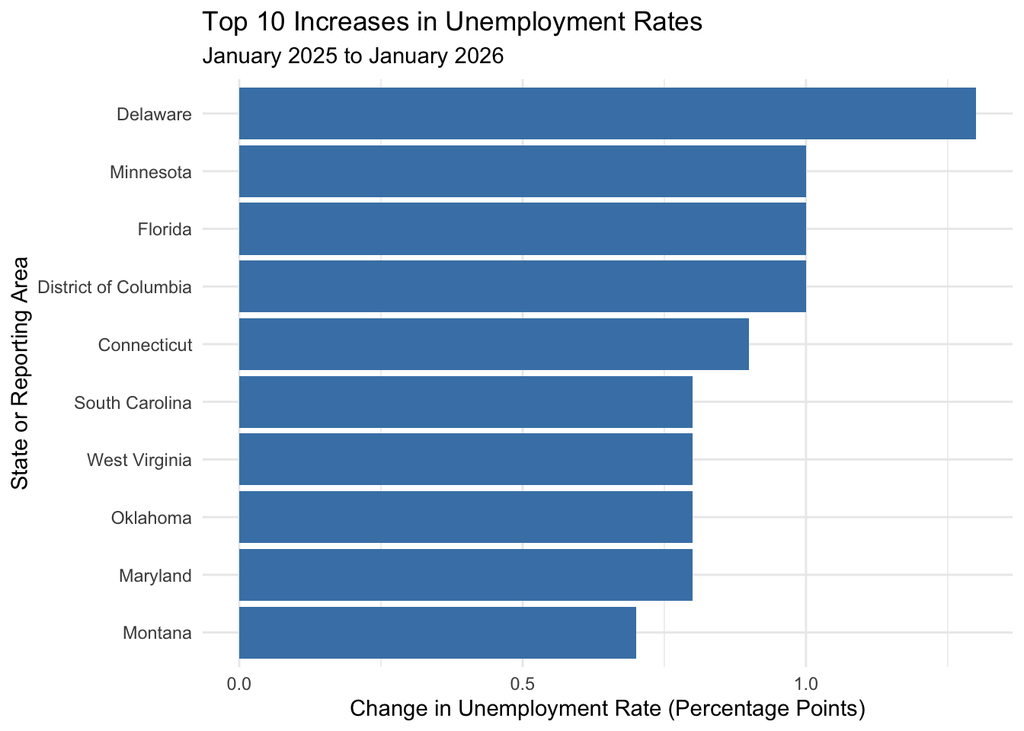

```r
# Select the ten largest increases
top_increases <- bls_changes |>
  dplyr::slice_max(
    order_by = change_points,
    n = 10,
    with_ties = FALSE
  )

# Create a bar chart
ggplot2::ggplot(
  top_increases,
  ggplot2::aes(
    x = reorder(state, change_points),
    y = change_points
  )
) +
  ggplot2::geom_col(fill = "steelblue") +
  ggplot2::coord_flip() +
  ggplot2::labs(
    title = "Top 10 Increases in Unemployment Rates",
    subtitle = "January 2025 to January 2026",
    x = "State or Reporting Area",
    y = "Change in Unemployment Rate (Percentage Points)"
  ) +
  ggplot2::theme_minimal()
```

## 9 Analyze New York’s Unemployment Rate Over Time

After comparing unemployment rates across different states, I want to examine how New York’s unemployment rate changed during the reporting periods available in the BLS dataset.

The previous analysis showed that New York’s unemployment rate increased from 4.1% in January 2025 to 4.6% in January 2026, an increase of 0.5 percentage points.

I will use dplyr to select New York’s unemployment measurements and ggplot2 to create a line chart showing the changes across the four available reporting periods.

```r
# Filter the dataset for New York
new_york_trend <- bls_tidy |>
  dplyr::filter(state == "New York") |>
  dplyr::arrange(period)

# Display New York's unemployment rates
print(
  new_york_trend |>
    dplyr::select(period, unemployment_rate)
)
```

```
# A tibble: 4 × 2
  period        unemployment_rate
  <fct>                     <dbl>
1 January 2025                4.1
2 November 2025               4.6
3 December 2025               4.6
4 January 2026                4.6
```

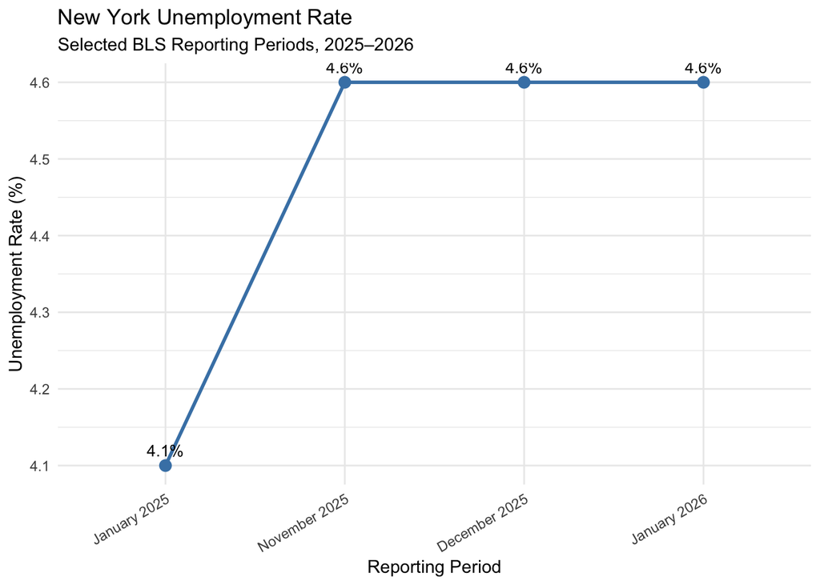

```r
# Create a line chart of New York's unemployment rates
ggplot2::ggplot(
  new_york_trend,
  ggplot2::aes(
    x = period,
    y = unemployment_rate,
    group = 1
  )
) +
  ggplot2::geom_line(
    color = "steelblue",
    linewidth = 1
  ) +
  ggplot2::geom_point(
    color = "steelblue",
    size = 3
  ) +
  ggplot2::geom_text(
    ggplot2::aes(
      label = paste0(unemployment_rate, "%")
    ),
    vjust = -0.8,
    size = 3.5
  ) +
  ggplot2::labs(
    title = "New York Unemployment Rate",
    subtitle = "Selected BLS Reporting Periods, 2025–2026",
    x = "Reporting Period",
    y = "Unemployment Rate (%)"
  ) +
  ggplot2::theme_minimal() +
  ggplot2::theme(
    axis.text.x = ggplot2::element_text(
      angle = 30,
      hjust = 1
    )
  )
```

## 10 Compare New York With Other States

After examining New York’s unemployment rate, I found that it increased from 4.1% in January 2025 to 4.6% in January 2026. The rate remained unchanged across the last three reporting periods included in the dataset.

I want to compare New York with California, New Jersey, Florida, and Texas to see how unemployment rates differ between these states.

I will use dplyr to select the states and ggplot2 to create a comparison chart showing their unemployment rates across the available reporting periods.

```r
# Select states for comparison
selected_states <- c(
  "New York",
  "California",
  "New Jersey",
  "Florida",
  "Texas"
)

# Filter the tidy dataset
state_comparison <- bls_tidy |>
  dplyr::filter(state %in% selected_states) |>
  dplyr::arrange(state, period)

# Display unemployment rates
print(
  state_comparison |>
    dplyr::select(state, period, unemployment_rate)
)
```

```
# A tibble: 20 × 3
   state      period        unemployment_rate
   <chr>      <fct>                     <dbl>
 1 California January 2025                5.4
 2 California November 2025               5.5
 3 California December 2025               5.5
 4 California January 2026                5.4
 5 Florida    January 2025                3.5
 6 Florida    November 2025               4.3
 7 Florida    December 2025               4.3
 8 Florida    January 2026                4.5
 9 New Jersey January 2025                4.9
10 New Jersey November 2025               5.4
11 New Jersey December 2025               5.4
12 New Jersey January 2026                5.2
13 New York   January 2025                4.1
14 New York   November 2025               4.6
15 New York   December 2025               4.6
16 New York   January 2026                4.6
17 Texas      January 2025                4.1
18 Texas      November 2025               4.3
19 Texas      December 2025               4.3
20 Texas      January 2026                4.3
```

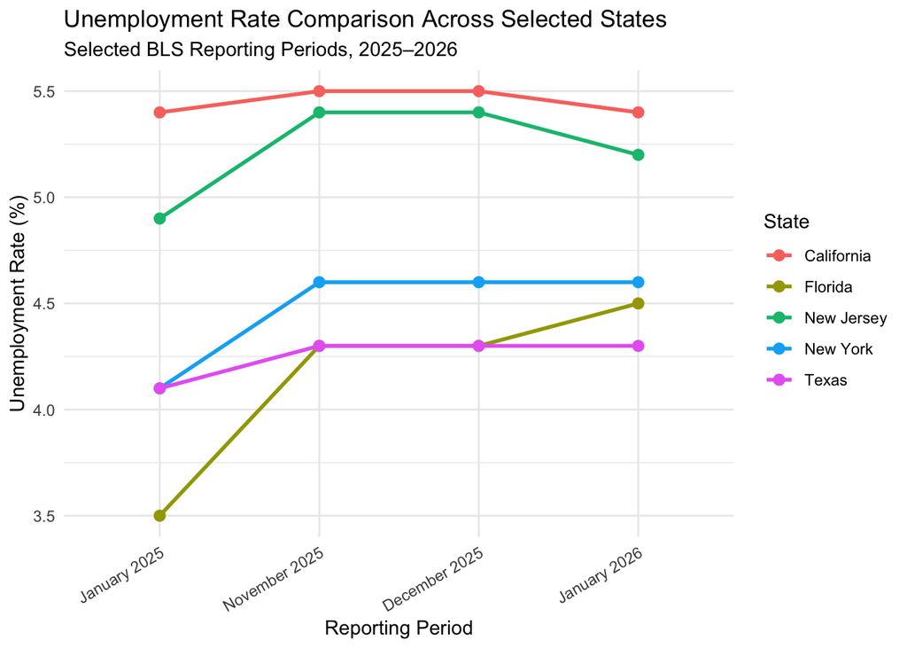

```r
# Create a comparison chart
ggplot2::ggplot(
  state_comparison,
  ggplot2::aes(
    x = period,
    y = unemployment_rate,
    color = state,
    group = state
  )
) +
  ggplot2::geom_line(linewidth = 1) +
  ggplot2::geom_point(size = 2.5) +
  ggplot2::labs(
    title = "Unemployment Rate Comparison Across Selected States",
    subtitle = "Selected BLS Reporting Periods, 2025–2026",
    x = "Reporting Period",
    y = "Unemployment Rate (%)",
    color = "State"
  ) +
  ggplot2::theme_minimal() +
  ggplot2::theme(
    axis.text.x = ggplot2::element_text(
      angle = 30,
      hjust = 1
    )
  )
```

## 11 Summary of Findings

After the cleaning process and the transformation of the database generated by the Bureau of Labor Statistics, it became possible to conduct a comparison of unemployment rates in 52 regions: 50 states, District of Columbia, and Puerto Rico. As the original database contained several columns with different time periods, this comparison was made possible due to the use of pivot_longer().

The comparative analysis of unemployment rates showed that 32 regions had a growth of unemployment rates from January 2025 to January 2026, while there were 10 regions with decreasing unemployment rates, and 10 regions had unemployment rates that remained unchanged. The average value of the increase of unemployment rate in the examined regions accounted for 0.24 percentage points per region.

Delaware had the biggest rise in unemployment rate, which went from 4.1% to 5.4%. The biggest drop in unemployment rates was noted in Indiana, Kentucky, and Ohio, which decreased by 0.5 percentage points.

Moreover, New York unemployment levels went up from 4.1% reached in January 2025 to 4.6% reached in January 2026. In January 2026, New York ranked as the 14th among the considered 52 regions in terms of unemployment level starting from the highest level of unemployment.

When comparing New York with California, New Jersey, Florida, and Texas, I found that California and New Jersey had higher unemployment rates throughout the selected reporting periods. Florida experienced an increase, while Texas showed smaller changes.

All in all, this project taught me how to tidy data so that I can analyze unemployment statistics between the different states and time periods involved. With the help of tidyr, dplyr, and ggplot2, I managed to reorganize the dataset, conduct necessary calculations, and produce visualizations that were difficult to generate from the original table in wide format.

## 12 Data Source and References

The dataset was obtained from the U.S. Bureau of Labor Statistics State Employment and Unemployment report published on April 8, 2026. The report contains information about civilian labor force participation, unemployed workers, and unemployment rates across states and other reporting areas.

For this analysis, I used Table 1 from the report. The original HTML report was uploaded to GitHub and imported directly into R using a raw GitHub link to make the analysis reproducible.

**Original BLS Report:**

https://www.bls.gov/news.release/archives/laus_04082026.htm

**GitHub Data Source:**

https://github.com/LBoodram26/Project-2

### 12.1 References

U.S. Bureau of Labor Statistics. (2026, April 8). *State employment and unemployment — January 2026.* https://www.bls.gov/news.release/archives/laus_04082026.htm

Wickham, H. (2014). Tidy data. *Journal of Statistical Software, 59*(10), 1–23. https://doi.org/10.18637/jss.v059.i10

Wickham, H., Vaughan, D., & Girlich, M. (2024). *tidyr: Tidy messy data.* https://tidyr.tidyverse.org/

Wickham, H., François, R., Henry, L., Müller, K., & Vaughan, D. (2023). *dplyr: A grammar of data manipulation.* https://dplyr.tidyverse.org/

Wickham, H., Navarro, D., & Pedersen, T. L. (2024). *ggplot2: Create elegant data visualisations using the grammar of graphics.* https://ggplot2.tidyverse.org/

Wickham, H. (2023). *rvest: Easily harvest (scrape) web pages.* https://rvest.tidyverse.org/